# ML_Coursera

Scott Jacobs

December 22, 2015

## Background

Using devices such as Jawbone Up, Nike FuelBand, and Fitbit it is now possible to collect a large amount of data about personal activity relatively inexpensively. These type of devices are part of the quantified self movement – a group of enthusiasts who take measurements about themselves regularly to improve their health, to find patterns in their behavior, or because they are tech geeks. One thing that people regularly do is quantify how much of a particular activity they do, but they rarely quantify how well they do it. In this project, your goal will be to use data from accelerometers on the belt, forearm, arm, and dumbell of 6 participants. They were asked to perform barbell lifts correctly and incorrectly in 5 different ways. More information is available from the website here: http://groupware.les.inf.puc-rio.br/har (see the section on the Weight Lifting Exercise Dataset).

## Project Results

Below are the dimensions of the Train and Test files respectively. Note: We have coerced to NA any missing, #DIV/0!, or NAs to NA.

### Data Read

```r
#install.packages(c("doParallel", "parallel", "caret", "data.table")
###########################Read in Data##############################
library(caret)
```

```r
library(data.table)
#create vector of strings that should be coerced to NA by the fread()
NAs <- c("", "NA", "#DIV/0!")
#establish URLs
trainUrl <-"https://d396qusza40orc.cloudfront.net/predmachlearn/pml-training.csv"
testUrl <- "https://d396qusza40orc.cloudfront.net/predmachlearn/pml-testing.csv"
#read URLs into objects
trainFile <- fread(trainUrl, na.strings = NAs, data.table=FALSE)
testFile  <- fread(testUrl, na.strings = NAs, data.table=FALSE)
dim(trainFile)
```

```
## [1] 19622   160
```

```r
dim(testFile)
```

```
## [1]  20 160
```

It’s now time to clean up the data. We only keep cols with less than 10% NA.

Below are the dimensions of the Train file after it has been cleaned up. It got rid of quite a few cols.

### Clean Data

[output not shown]

We create two smaller data sets from the Training file for cross-validation;

1.) training and 2.) probing.

Training will be used to fit the model. Probing will be used to verify the results.

### Data Splitting and Pre-Processing

```r
################## Pre-Proc, Data Splitting #######################
preProcValues <- preProcess(trainingProc, method = c("center", "scale"))
#use the pre-processed values to transform the training data
trainTransformed <- predict(preProcValues, trainFile)
testTransformed <- predict(preProcValues, testFile)
#add back in classe to the training data, keep only the cols we used in preProc
trainTransformed <- trainTransformed[,c(names(trainingProc),"classe")]
testTransformed <- testTransformed[,c(names(trainingProc))]

set.seed(545)
#create training and probing sets from the original training set
TrainRows <- createDataPartition(y=trainTransformed$classe, p=.7, list=F)
training <- trainTransformed[TrainRows,]
probing <- trainTransformed[-TrainRows,]
dim(training)
```

```
## [1] 13737    32
```

```r
dim(probing)
```

```
## [1] 5885   32
```

We are using the random forest model along with K-Folds (10) cross-validation. The model is then used to predict on the probing data set.

### Model Building

```r
########################## Model Building #########################
#Let's make this go faster
require(parallel)
require(doParallel)
cores <- makeCluster(detectCores() - 1)
registerDoParallel(cores)


#create Random Forrest Model, use k-folds cross validation (10 folds)
#use the training set we just created from the partitioned data above
modFit <- train(classe ~ ., data = training,
                method = "rf", trControl = trainControl(method = "repeatedcv", repeats = 10))
```

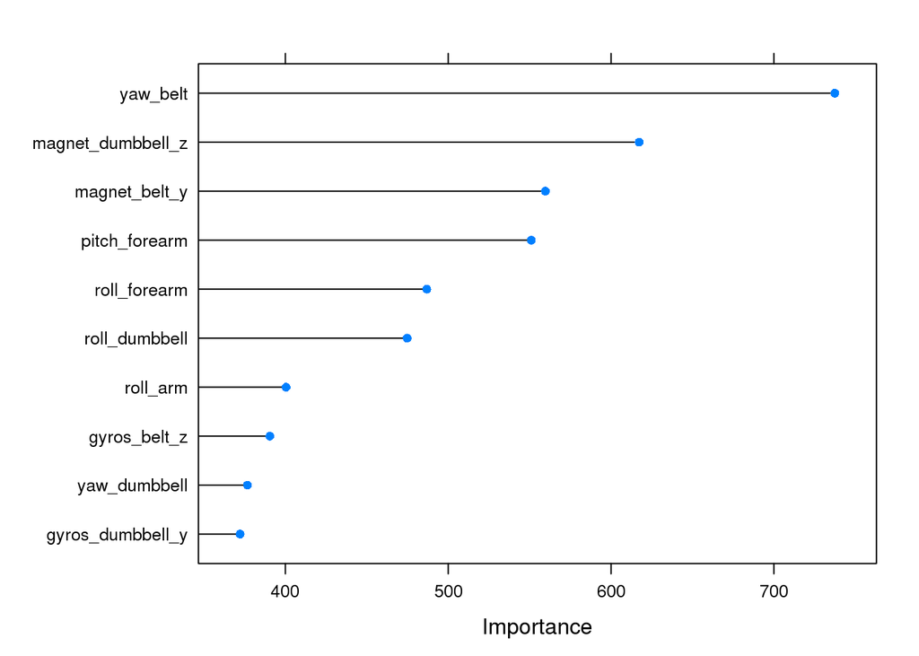

```r
#identify important variables
importance <- varImp(modFit, scale = FALSE)
#plot the top 10 important variables
plot(importance, top = 10)
```

```r
#review the model
summary(modFit)
```

```
##                 Length Class      Mode
## call                4  -none-     call
## type                1  -none-     character
## predicted       13737  factor     numeric
## err.rate         3000  -none-     numeric
## confusion          30  -none-     numeric
## votes           68685  matrix     numeric
## oob.times       13737  -none-     numeric
## classes             5  -none-     character
## importance         31  -none-     numeric
## importanceSD        0  -none-     NULL
## localImportance     0  -none-     NULL
## proximity           0  -none-     NULL
## ntree               1  -none-     numeric
## mtry                1  -none-     numeric
## forest             14  -none-     list
## y               13737  factor     numeric
## test                0  -none-     NULL
## inbag               0  -none-     NULL
## xNames             31  -none-     character
## problemType         1  -none-     character
## tuneValue           1  data.frame list
## obsLevels           5  -none-     character
```

```r
#validate the model with the probing data set we created in the partition
pred <- predict(modFit, probing)
summary(pred)
```

```
##    A    B    C    D    E
## 1679 1142 1029  953 1082
```

```r
stopCluster(cores)
```

The results of the in sample error rate are represented by the call to modFit. The out of sample error rate is given by calling the confusion matrix on the probing data. The error is very low in both cases, and even lower in the final fitted model. This is unusual but the instructors likely made this a very “solvable” problem :)

### Results

```r
############################## Results ################################
#Here are the in sample error rates
modFit
```

```
## Random Forest
##
## 13737 samples
##    31 predictor
##     5 classes: 'A', 'B', 'C', 'D', 'E'
##
## No pre-processing
## Resampling: Cross-Validated (10 fold, repeated 10 times)
## Summary of sample sizes: 12365, 12362, 12363, 12362, 12363, 12363, ...
## Resampling results across tuning parameters:
##
##   mtry  Accuracy   Kappa      Accuracy SD  Kappa SD
##    2    0.9898889  0.9872092  0.002516082  0.003183255
##   16    0.9892697  0.9864252  0.002953750  0.003737479
##   31    0.9773316  0.9713239  0.004122075  0.005215687
##
## Accuracy was used to select the optimal model using  the largest value.
## The final value used for the model was mtry = 2.
```

```r
#Here are the out of sample error rates
confusionMatrix(pred, probing$classe)
```

```
## Confusion Matrix and Statistics
##
##           Reference
## Prediction    A    B    C    D    E
##          A 1671    8    0    0    0
##          B    2 1127   13    0    0
##          C    0    4 1010   14    1
##          D    0    0    3  950    0
##          E    1    0    0    0 1081
##
## Overall Statistics
##
##                Accuracy : 0.9922
##                  95% CI : (0.9896, 0.9943)
##     No Information Rate : 0.2845
##     P-Value [Acc > NIR] : < 2.2e-16
##
##                   Kappa : 0.9901
##  Mcnemar's Test P-Value : NA
##
## Statistics by Class:
##
##                      Class: A Class: B Class: C Class: D Class: E
## Sensitivity            0.9982   0.9895   0.9844   0.9855   0.9991
## Specificity            0.9981   0.9968   0.9961   0.9994   0.9998
## Pos Pred Value         0.9952   0.9869   0.9815   0.9969   0.9991
## Neg Pred Value         0.9993   0.9975   0.9967   0.9972   0.9998
## Prevalence             0.2845   0.1935   0.1743   0.1638   0.1839
## Detection Rate         0.2839   0.1915   0.1716   0.1614   0.1837
## Detection Prevalence   0.2853   0.1941   0.1749   0.1619   0.1839
## Balanced Accuracy      0.9982   0.9932   0.9902   0.9924   0.9994
```

```r
#predict classe using the mdoel on the test data
predTest <- predict(modFit, testTransformed)
summary(predTest)
```

```
## A B C D E
## 7 8 1 1 3
```